# Demonstration of HyperTraPS in R

HyperTraPS (hypercubic transition path sampling) is a family of algorithms for inferring the dynamics of “accumulation” processes. These are processes where a set of binary features are acquired over time.

HyperTraPS will take a set of observed states, described by binary strings recording the presence/absence of each feature. It may optionally take initial states from which these states are reached, and information on the timings associated with each observation. It returns various summaries of which feature are acquired and when, and how these features influence each other.

### Loading the software

If we just want the HyperTraPS code without other dependencies, we only need Rcpp, and can use the following

```r
library(Rcpp)
sourceCpp("hypertraps-r.cpp")
```

If we want various helper functions and ggplot functions in addition, use this

```r
source("hypertraps.R")
```

### Simple demo

Here we’ll construct a simple synthetic dataset. The `m.1` matrix will store a set of initial states, and the `m.2` matrix will store a set of later observed states. The first row of `m.1`, for example, stores the state 00000, where no features have been acquired. The first row of `m.2` stores 10000, where the first of five features has been acquired.

The times correspond to each observation, so the transition 00000->10000 described by those first rows has an associated time of 0.1 (in whatever units we are working with).

```r
m.1 = matrix(rep(c(0,0,0,0,0,
               1,0,0,0,0,
               1,1,0,0,0,
               1,1,1,0,0,
               1,1,1,1,0,
               0,0,0,0,0,
               0,0,0,0,1,
               0,0,0,1,1,
               0,0,1,1,1,
               0,1,1,1,1),5), byrow=TRUE, ncol=5)
m.2 = matrix(rep(c(1,0,0,0,0,
               1,1,0,0,0,
               1,1,1,0,0,
               1,1,1,1,0,
               1,1,1,1,1,
               0,0,0,0,1,
               0,0,0,1,1,
               0,0,1,1,1,
               0,1,1,1,1,
               1,1,1,1,1),5), byrow=TRUE, ncol=5)
times = rep(c(0.1, 0.2, 0.3, 0.4, 0.5), 10)
```

Let’s run HyperTraPS with these “before” and “after” observations. By using `times` as both the start and end time arguments, we say that each transition takes precisely that associated time – we could allow broader time windows to capture uncertainty in timing. Finally, we provide labels for the five individual features involved.

```r
my.post = HyperTraPS(m.2, initialstates_arg = m.1,
                     starttimes_arg = times, endtimes_arg = times,
                     featurenames_arg = c("A", "B", "C", "D", "E"))
```

```
##
## HyperTraPS(-CT)
## Sep 2023
##
## Unpublished code -- please do not circulate!
## Published version available at:
##     https://github.com/StochasticBiology/HyperTraPS
## with stripped-down version at:
##     https://github.com/StochasticBiology/hypertraps-simple
##
## Running HyperTraPS-CT with:
## [observations-file]: rcpp
## [start-timings-file]:
## [end-timings-file]:
## [random number seed]: 1
## [length index]: 3
## [kernel index]: 5
## [walkers]: 200
## [losses (1) or gains (0)]: 0
## [APM]: 0
## [model]: 2
##
## Using MH MCMC
## Number of features is 5, I found 50 observation pairs and 50 timing pairs
##
## Starting with simple initial param guess
## One likelihood estimation took 1.177000e-03 seconds.
## Initial likelihood is -9.033188e+01
## Second guess is -9.033188e+01
## This code (1000 steps) will probably take around 1.177 seconds (0.000 hours) to complete.
##
## 0 - Iteration 0 likelihood -90.331879 total-acceptance 0.000000 recent-acceptance 0.000000 trial-likelihood -99.386252
## 100 - Iteration 100 likelihood -66.809091 total-acceptance 0.207921 recent-acceptance 0.210000 trial-likelihood -73.963469
## 200 - Iteration 200 likelihood -55.969824 total-acceptance 0.218905 recent-acceptance 0.230000 trial-likelihood -60.264649
## 300 - Iteration 300 likelihood -51.245479 total-acceptance 0.199336 recent-acceptance 0.160000 trial-likelihood -57.876586
## 400 - Iteration 400 likelihood -53.015445 total-acceptance 0.214464 recent-acceptance 0.260000 trial-likelihood -57.437495
## 500 - Iteration 500 likelihood -55.544181 total-acceptance 0.211577 recent-acceptance 0.200000 trial-likelihood -56.438726
## 600 - Iteration 600 likelihood -50.854181 total-acceptance 0.212978 recent-acceptance 0.220000 trial-likelihood -54.143414
## 700 - Iteration 700 likelihood -51.469557 total-acceptance 0.206847 recent-acceptance 0.170000 trial-likelihood -60.168949
## 800 - Iteration 800 likelihood -49.285480 total-acceptance 0.205993 recent-acceptance 0.200000 trial-likelihood -49.285480
## 900 - Iteration 900 likelihood -50.881319 total-acceptance 0.216426 recent-acceptance 0.300000 trial-likelihood -50.881319
##
## HyperTraPS(-CT) posterior analysis
##
## Verbose flag is 0
## Bin scale is 10.000000
## Using posterior samples with 7 x 25 entries
## Based on rcpp with 25 params per model and model 2, there are 5 features
## Output label is rcpp
## allruns is 70
## 0 1.524714
## 1 2.030571
## 2 2.138429
## 3 2.353143
## 4 1.953143
```

Here’s a “bubble” plot summary of the inferred dynamics. The size of a circle at point x,y gives the probability that feature y is acquired at ordinal time x.

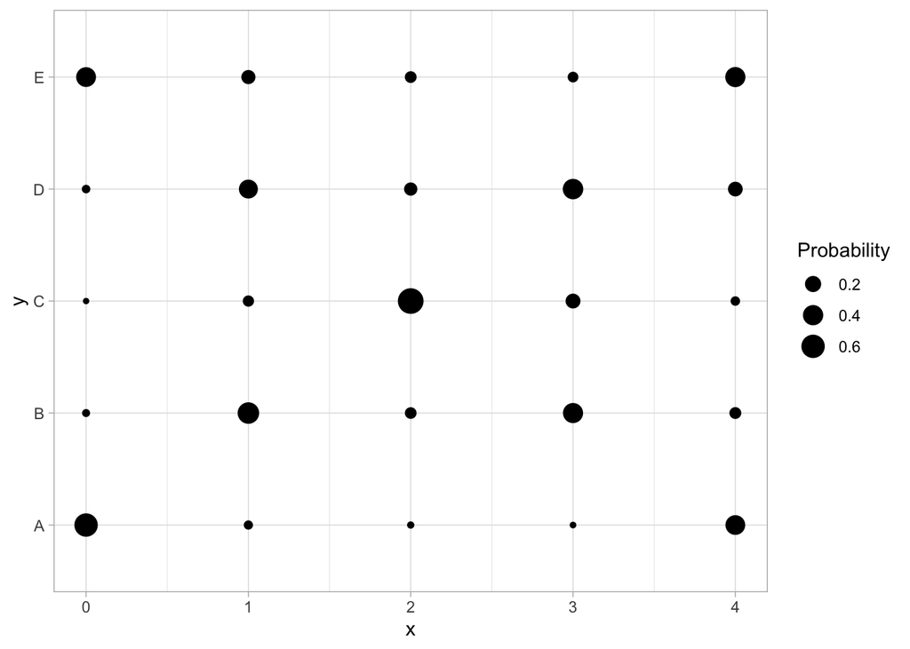

```r
plotHypercube.bubbles(my.post)
```

This plot shows a set of sampled routes on the hypercubic space. Each edge is a transition, corresponding to the acquisition of a new feature. The edges are labelled by the feature acquired and the statistics of the time taken (mean +- s.d.). The edge width gives the probability flux through that transition.

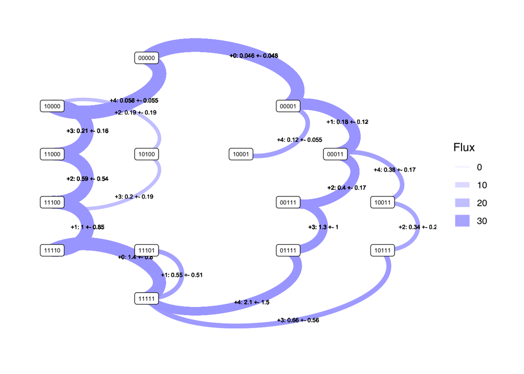

```r
plotHypercube.sampledgraph2(my.post)
```

### Input/output between R data structure and file format

We can write the output of HyperTraPS to a set of files for storage and later retrieval

```r
writeHyperinf(my.post, "simpledemo", my.post$L, postlabel = "simpledemo", fulloutput=TRUE)
```

We can retrieve output from files, which may have been previously written as above, or may have come from running HyperTraPS at the command line.

```r
my.post.r = readHyperinf("simpledemo", postlabel = "simpledemo", fulloutput=TRUE)
```

### Other visualisations

Next we’ll look at some other ways of visualising the output of HyperTraPS.

Motif plot, containing the same data as the bubble plots but via different visualisation

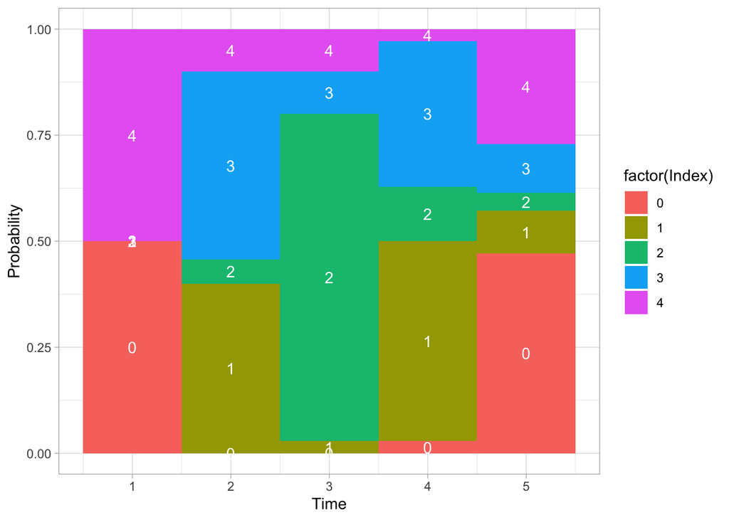

```r
plotHypercube.motifs(my.post)
```

Time series plot. Each step up the vertical axis corresponds to the acquisition of a new feature. The horizontal axis gives the time of the corresponding event, and the colour labels the feature that was acquired.

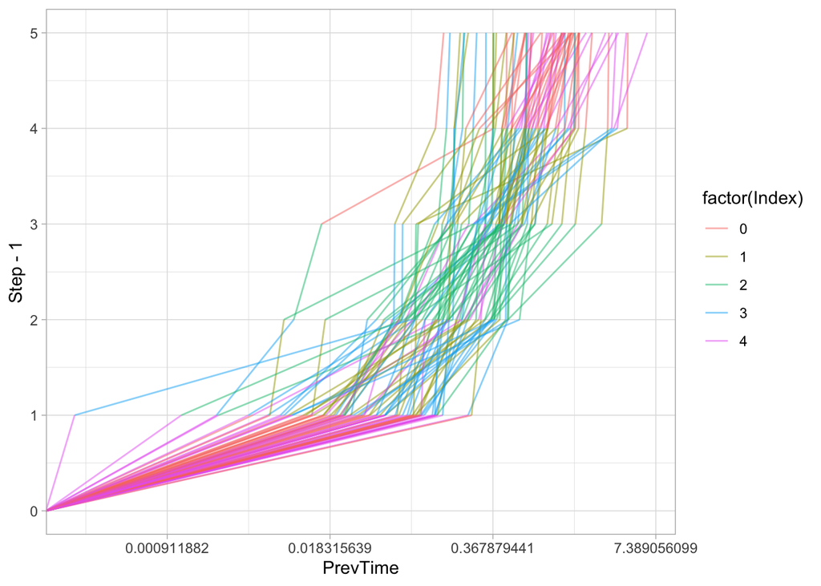

```r
plotHypercube.timeseries(my.post)
```

### Other functional examples

HyperTraPS allows substantial flexibility in how evolutionary pathways are inferred, how likelihoods are estimated, and other aspects of the approach.

If we want to sacrifice some accuracy in estimating likelihood for computational speed, we can run an example with fewer walkers sampling pathways (`walkers_arg`)

```r
my.post.sparse = HyperTraPS(m.2, initialstates_arg = m.1,
                            starttimes_arg = times, featurenames_arg = c("A", "B", "C", "D", "E"),
                            walkers_arg = 2,
                            limited_output_arg = 1)
```

```
## Start timings, but not end timings, specified. Assuming t = inf ends.
## One likelihood estimation took 3.900000e-05 seconds.
## Initial likelihood is -7.482955e+01
## Second guess is -7.482955e+01
## This code (1000 steps) will probably take around 0.039 seconds (0.000 hours) to complete.
##
## 0 - 100 - 200 - 300 - 400 - 500 - 600 - 700 - 800 - 900 -
```

We can ask HyperTraPS to perform stepwise regularisation after fitting a model, pruning extraneous parameters (`regularise_arg`). The regularisation plot shows how the information criterion behaves as we prune back parameters – the minimum gives us our optimal model.

```r
my.post.regularise = HyperTraPS(m.2, initialstates_arg = m.1, regularise_arg = 1,
                                walkers_arg = 20,
                                limited_output_arg = 1)
```

```
## One likelihood estimation took 1.260000e-04 seconds.
## Initial likelihood is -4.787492e+01
## Second guess is -4.787492e+01
## This code (1000 steps) will probably take around 0.126 seconds (0.000 hours) to complete.
##
## 0 - 100 - 200 - 300 - 400 - 500 - 600 - 700 - 800 - 900 -
```

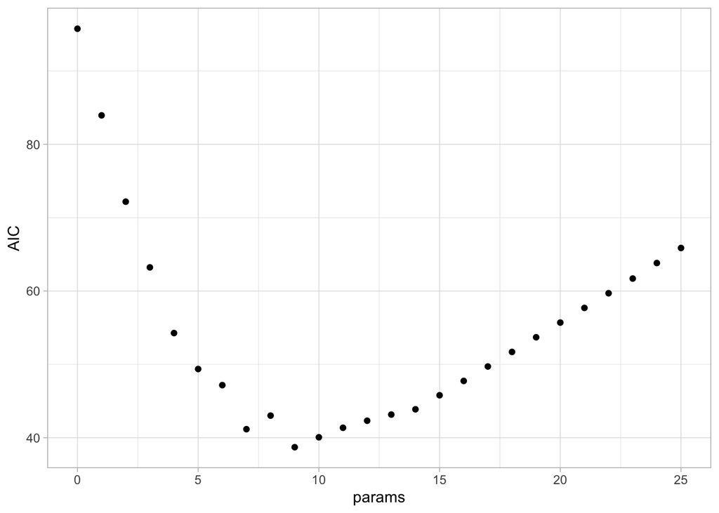

```r
plotHypercube.regularisation(my.post.regularise)
```

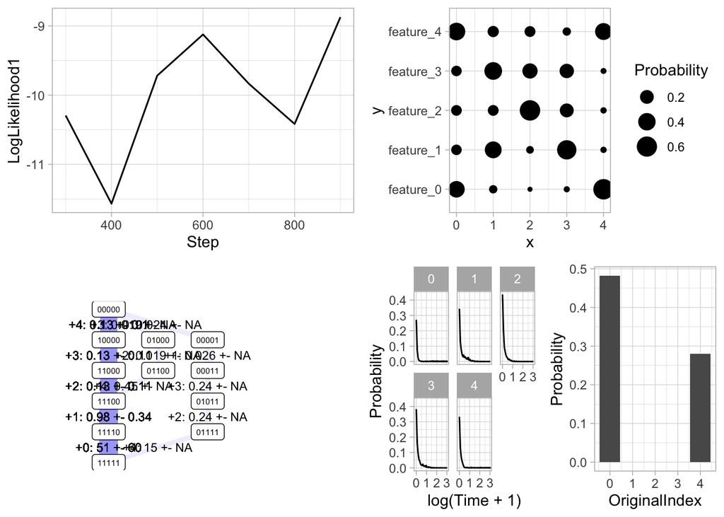

```r
plotHypercube.summary(my.post.regularise)
```

We can use simulated annealing to get a maximum likelihood estimate rather than a Bayesian picture (`sa_arg`)

```r
my.post.sa = HyperTraPS(m.2, initialstates_arg = m.1, sa_arg = 1,
                        limited_output_arg = 1)
```

```
## One likelihood estimation took 9.970000e-04 seconds.
## Initial likelihood is -4.787492e+01
## Second guess is -4.787492e+01
## This code (1000 steps) will probably take around 0.997 seconds (0.000 hours) to complete.
##
## 0 - 100 - 200 - 300 - 400 - 500 - 600 - 700 - 800 - 900 -
```

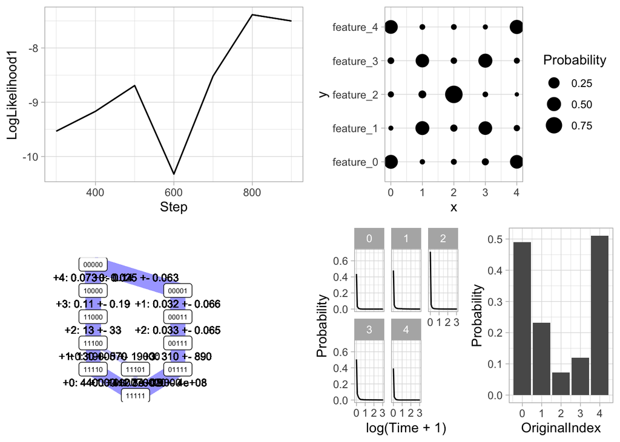

```r
plotHypercube.summary(my.post.sa)
```

We can also use “phenotype landscape inference” – an unbiased sampling method, unlike the (corrected) bias sampling in HyperTraPS (`PLI_arg`). This takes longer but is more flexible with uncertain data

```r
my.post.pli = HyperTraPS(m.2, initialstates_arg = m.1, PLI_arg = 1,
                         limited_output_arg = 1)
```

```
## One likelihood estimation took 6.283000e-03 seconds.
## Initial likelihood is -2.912900e+02
## Second guess is -2.906914e+02
## This code (1000 steps) will probably take around 6.283 seconds (0.002 hours) to complete.
##
## 0 - 100 - 200 - 300 - 400 - 500 - 600 - 700 - 800 - 900 -
```

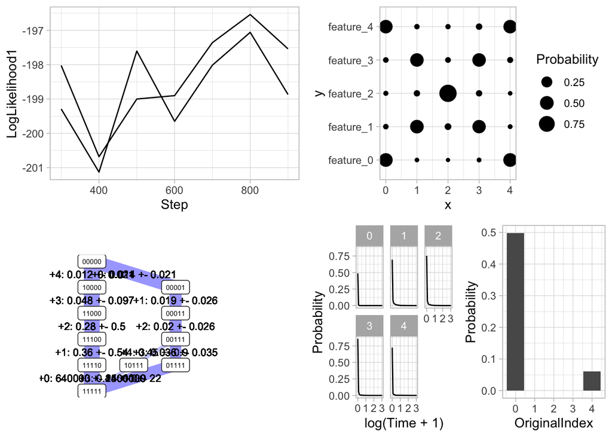

```r
plotHypercube.summary(my.post.pli)
```

HyperTraPS supports different parameter structures (`model_arg`). By default we use an “L2” parameterisation, where each feature can individually influence the acquisition of every other feature. “L1” has features completely independent; “L0” has all features identical. “L3” allows *pairs* of features to influence each feature’s acquisition; “L4” allows *triplets* of features to influence each feature’s acquisition. This approach, labelled -1, allows every edge on the hypercube to have its own independent parameters – corresponding to the most flexible possible picture, where arbitrary sets of features influence other features. We then regularise as above (`regularise_arg`) to remove extraneous parameters

```r
my.post.bigmodel.regularise = HyperTraPS(m.2, initialstates_arg = m.1, model_arg = -1,
                                         regularise_arg = 1, walkers_arg = 20,
                                         limited_output_arg = 1)
```

```
## One likelihood estimation took 1.090000e-04 seconds.
## Initial likelihood is -4.787492e+01
## Second guess is -4.787492e+01
## This code (1000 steps) will probably take around 0.109 seconds (0.000 hours) to complete.
##
## 0 - 100 - 200 - 300 - 400 - 500 - 600 - 700 - 800 - 900 -
```

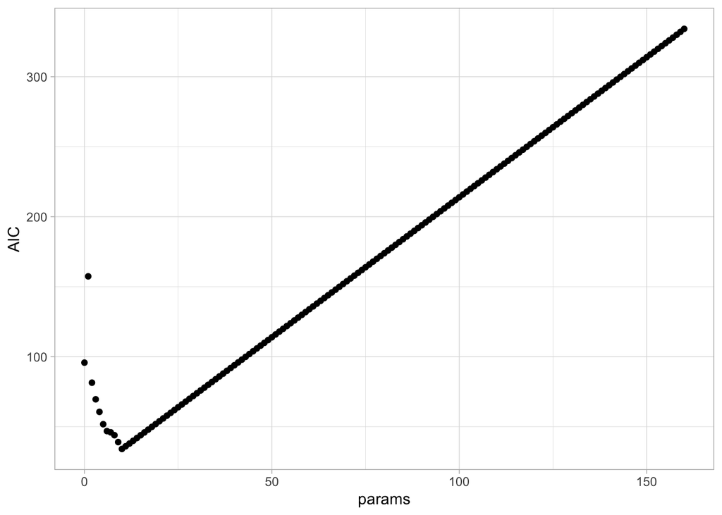

```r
plotHypercube.regularisation(my.post.bigmodel.regularise)
```

### Scientific examples

A set of short-form examples from past studies – these should run in a few minutes and give approximations to the original results. In each case we read the observed states from a file (these are present in different formats, so different curation steps are involved in each case), and feature labels from another file. Then we run HyperTraPS and plot some summaries of the output.

1. Ovarian cancer case study: traits are chromosomal aberrations, observations are independent patient samples.

```r
cgh.mat = readLines("RawData/ovarian.txt")
cgh.mat = do.call(rbind, lapply(strsplit(cgh.mat, ""), as.numeric))
cgh.names = as.vector(read.table("RawData/ovarian-names.txt", sep=","))[[1]]

my.post.cgh = HyperTraPS(cgh.mat,
                        length_index_arg = 3, outputinput_arg = 1,
                        featurenames_arg = cgh.names,
                        limited_output_arg = 1)
```

```
## Observed transitions:
## 0: 0000000 -> 0000010
## 1: 0000000 -> 0001010
## 2: 0000000 -> 1111000
## 3: 0000000 -> 1000000
## 4: 0000000 -> 0000000
## 5: 0000000 -> 1111100
## 6: 0000000 -> 1111101
## 7: 0000000 -> 0110000
## 8: 0000000 -> 0100001
## 9: 0000000 -> 1011111
## 10: 0000000 -> 0000000
## 11: 0000000 -> 1111101
## 12: 0000000 -> 1111111
## 13: 0000000 -> 1110011
```

[output cut: 81 more lines]

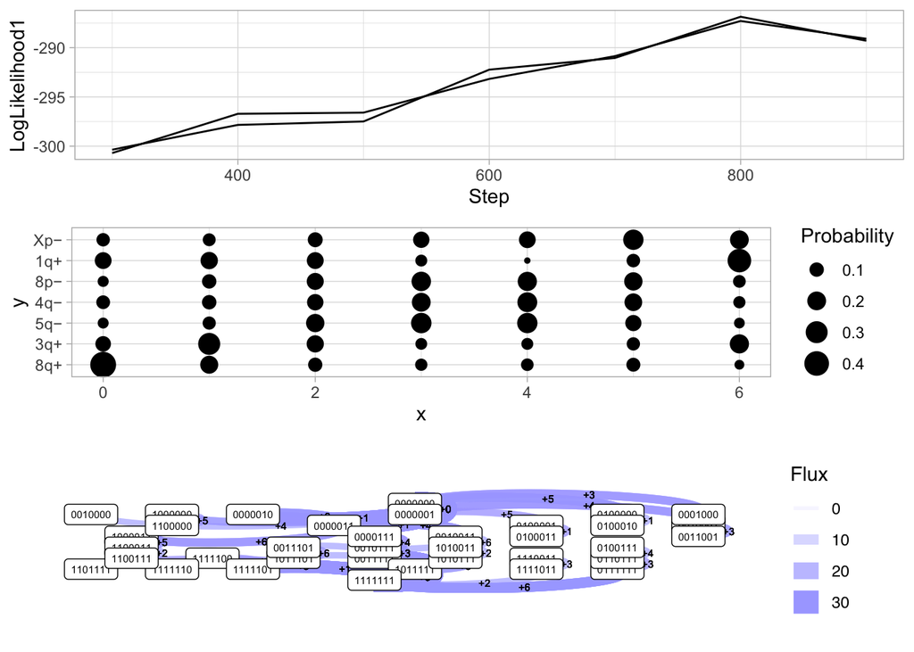

```r
ggarrange(plotHypercube.lik.trace(my.post.cgh),
          plotHypercube.bubbles(my.post.cgh, reorder=TRUE),
          plotHypercube.sampledgraph2(my.post.cgh, no.times=TRUE), nrow=3)
```

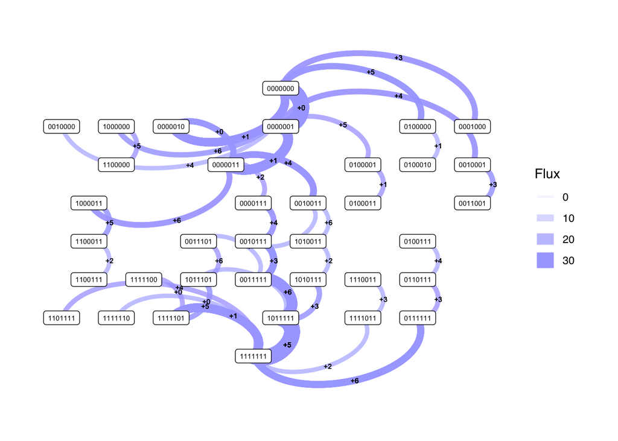

```r
plotHypercube.sampledgraph2(my.post.cgh, no.times=TRUE)
```

2. C4 photosynthesis case study: traits are physical/genetic features associated with C4, observations are (incomplete) phylogenetically independent intermediate species.

This case study involves some uncertain data, which are present as “2”s in the source data – labelling features which may be 0 or 1.

```r
c4.mat = as.matrix(read.table("RawData/c4-curated.csv", sep=","))
c4.names = as.vector(read.table("RawData/c4-trait-names.txt", sep=","))[[1]]

my.post.c4 = HyperTraPS(c4.mat,
                        length_index_arg = 3,
                        losses_arg = 1,
                        featurenames_arg = c4.names,
                        limited_output_arg = 1)
```

```
## One likelihood estimation took 3.990500e-02 seconds.
## Initial likelihood is -2.694082e+02
## Second guess is -2.695834e+02
## This code (1000 steps) will probably take around 39.905 seconds (0.011 hours) to complete.
##
## 0 - 100 - 200 - 300 - 400 - 500 - 600 - 700 - 800 - 900 -
```

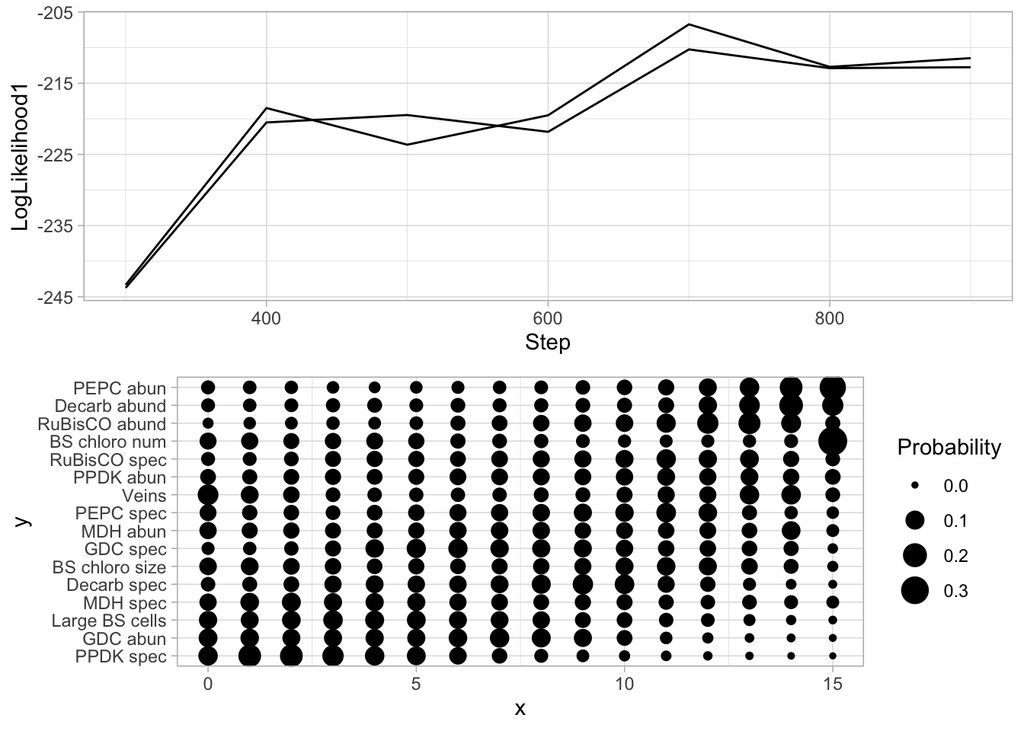

```r
ggarrange(plotHypercube.lik.trace(my.post.c4), plotHypercube.bubbles(my.post.c4, reorder=TRUE), nrow=2)
```

3. Severe malaria disease progression case study: traits are clinical features, observations are (incomplete) independent patient presentations

```r
malaria.df = read.csv("RawData/jallow_dataset_binary_with2s.csv")
malaria.mat = as.matrix(malaria.df[,2:ncol(malaria.df)])
malaria.names = as.vector(read.table("RawData/malaria-names.txt", sep=","))[[1]]

my.post.malaria = HyperTraPS(malaria.mat,
                        length_index_arg = 3,
                        kernel_index_arg = 2,
                        walkers_arg = 20,
                        featurenames_arg = malaria.names,
                        limited_output_arg = 1)
```

```
## One likelihood estimation took 1.790491e+00 seconds.
## Initial likelihood is -7.672008e+04
## Second guess is -7.671213e+04
## This code (1000 steps) will probably take around 1790.491 seconds (0.497 hours) to complete.
##
## 0 - 100 - 200 - 300 - 400 - 500 - 600 - 700 - 800 - 900 -
```

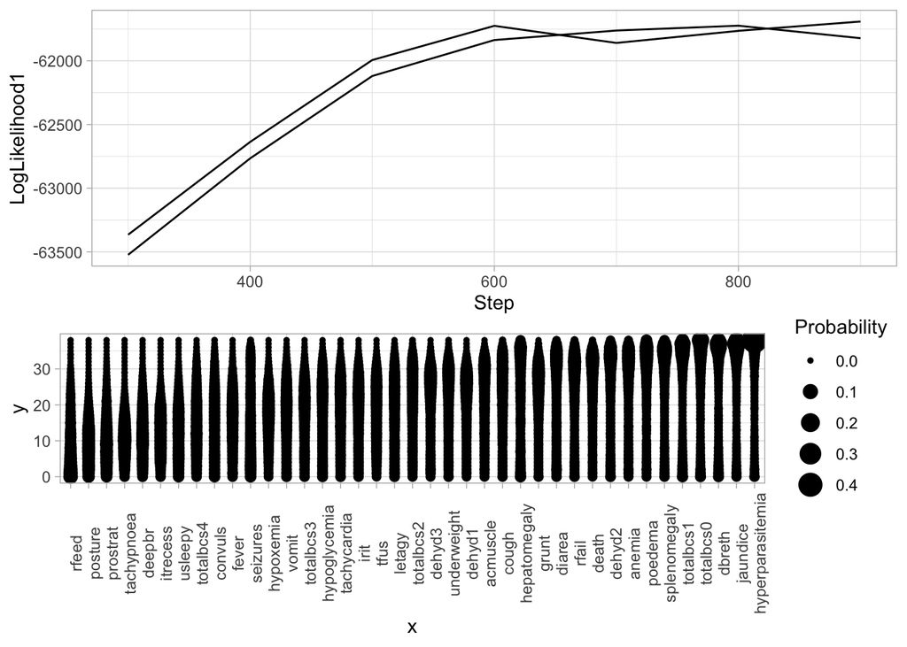

```r
ggarrange(plotHypercube.lik.trace(my.post.malaria), plotHypercube.bubbles(my.post.malaria, reorder=TRUE, transpose=TRUE), nrow=2)
```

4. Tool use evolution case study: traits are modes of tool use, observations are phylogenetically coupled species observations (phylogeny has been accounted for, giving transition pairs)

```r
tools.mat = as.matrix(read.table("RawData/total-observations.txt-trans.txt"))
tools.names = as.vector(read.table("RawData/tools-names.txt"))[[1]]
tools.starts = tools.mat[seq(from=1, to=nrow(tools.mat), by=2),]
tools.ends = tools.mat[seq(from=2, to=nrow(tools.mat), by=2),]

my.post.tools = HyperTraPS(tools.ends, initialstates_arg = tools.starts,
                           length_index_arg = 3,
                           featurenames_arg = tools.names,
                           limited_output_arg = 1)
```

```
## One likelihood estimation took 1.615700e-02 seconds.
## Initial likelihood is -1.811798e+02
## Second guess is -1.811798e+02
## This code (1000 steps) will probably take around 16.157 seconds (0.004 hours) to complete.
##
## 0 - 100 - 200 - 300 - 400 - 500 - 600 - 700 - 800 - 900 -
```

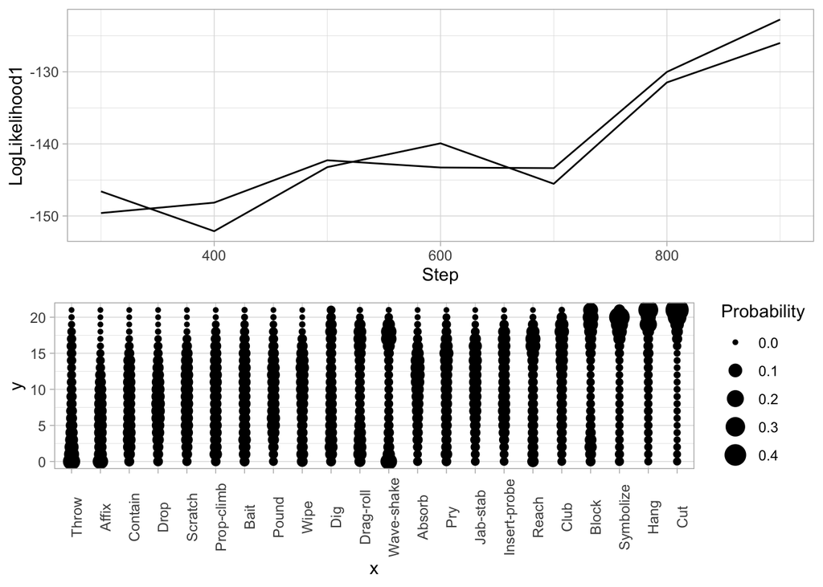

```r
ggarrange(plotHypercube.lik.trace(my.post.tools), plotHypercube.bubbles(my.post.tools, reorder=TRUE, transpose=TRUE), nrow=2)
```

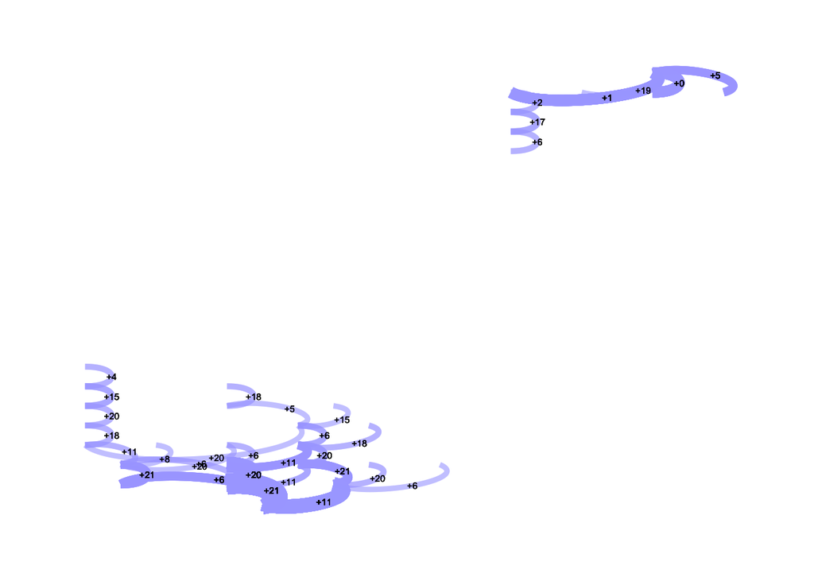

```r
plotHypercube.sampledgraph2(my.post.tools, node.labels = FALSE, max=100, no.times=TRUE) + theme(legend.position = "none")
```

Here we can plot quick summaries of all scientific case studies

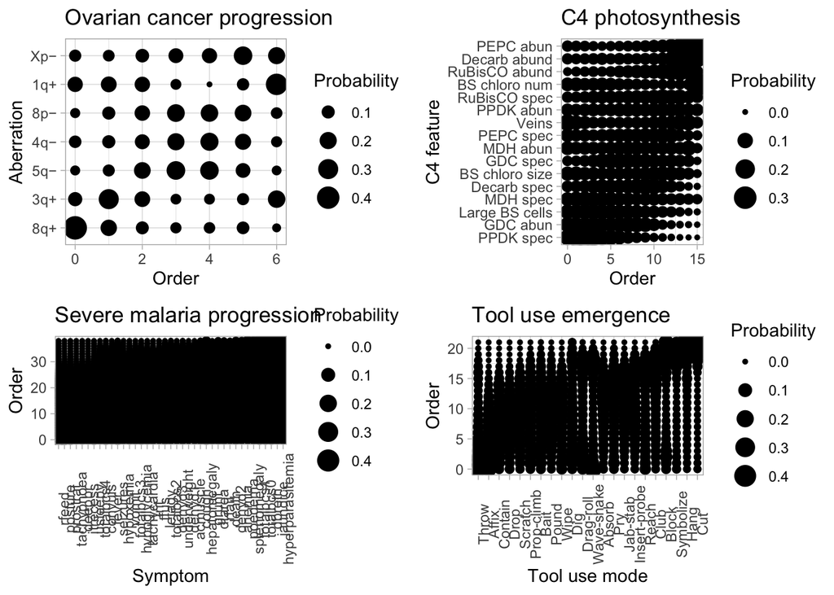

```r
ggarrange( plotHypercube.bubbles(my.post.cgh, reorder=TRUE) + xlab("Order") + ylab("Aberration") + ggtitle("Ovarian cancer progression"),
           plotHypercube.bubbles(my.post.c4, reorder=TRUE) + xlab("Order") + ylab("C4 feature") + ggtitle("C4 photosynthesis"),
           plotHypercube.bubbles(my.post.malaria, reorder=TRUE, transpose=TRUE) + xlab("Symptom") + ylab("Order") + ggtitle("Severe malaria progression"),
           plotHypercube.bubbles(my.post.tools, reorder=TRUE, transpose=TRUE) + xlab("Tool use mode") + ylab("Order") + ggtitle("Tool use emergence"))
```